# Sampling

## Survey error

## Total Survey Error

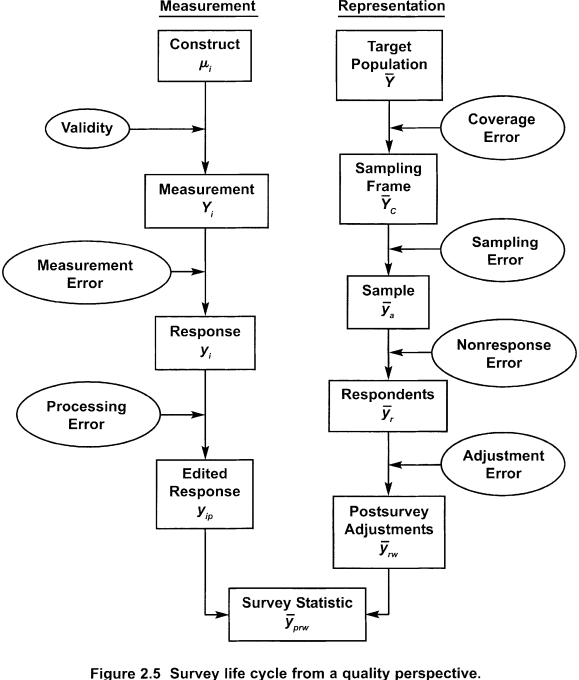

From (Groves et al. 2009)

## Total Survey error

- Errors of representation appear when there is some difference between who we end up measuring and who we want to measure.
- The target population is some finite set of observations we want to know something about.

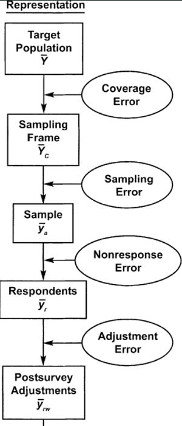

## Target Populations

- The American National Election Study targets U.S. citizens age 18 or older living in the 48 contiguous states of the U.S. or Washington, D.C. during a period prior to or just after a U.S. presidential election.
- National Health and Nutrition Examination Survey targets the non-institutionalized civilian resident population of the U.S. in a given year.
- The Youth Risk Behavior Survey targets public and private school students in grades 9-12 in the United States in a given year.

## Surveying the whole population

- The U.S. Census try to measure the entire population of interest.
- Obviously this is not practical for most surveys that seek to measure something about the U.S. population.

[figure not shown]

## Not surveying the whole population

- More often, surveys will attempt to measure some sample of the target population.
- The hope is that the sampled units are representative of the target population, but to the extent they’re not, this introduces new sources of error.

## Sampling Frames

- A sampling frame is the list of elements in the target population
- A list of elements isn’t always available: we might have a list of phone numbers, but not “all adults in the U.S.”

[figure not shown]

## Sampling Frames and coverage error

Coverage error results from differences between the sampling frame and the target population.

- For example: we might want to measure all U.S. citizens, but our list of phone numbers leaves out unlisted numbers and people without phones.
- Random digit dialing gives a way around the first problem, but not the second.

## Sampling Error

Sampling error is the gap between the sampling frame and the sample.

- This is always present when we sample, but under the right conditions, we can say a lot about the likelihood of an error of a given size.

## Sampling Distributions

The sampling distribution is the distribution of sample statistics across *all possible realizations of a sample.*

## Sampling Distributions

```
flowchart TB
    pop(["🫧 Population
    true mean: μ, std dev: σ"])

    subgraph samples["📋 Samples of size n"]
        s1["Sample 1
        {y₁, y₂, …, yₙ}"]
        s2["Sample 2
        {y₁, y₂, …, yₙ}"]
        s3["Sample 3
        {y₁, y₂, …, yₙ}"]
        sk["Sample k
        {y₁, y₂, …, yₙ}"]
    end

    subgraph stats["🧮 Sample means"]
        t1(["̄y₁"])
        t2(["̄y₂"])
        t3(["̄y₃"])
        tk(["̄yₖ"])
    end

    hist["Sampling Distribution of ̄y
    ─────────────────────
    ░░░░░██▌░░░░░
    ░░░░████▌░░░░
    ░░░██████▌░░░
    ░░████████▌░░
    ─────────────────────
"]

    pop -->|"draw"| s1
    pop -->|"draw"| s2
    pop -->|"draw"| s3
    pop -->|"draw"| sk

    s1 --> t1
    s2 --> t2
    s3 --> t3
    sk --> tk

    t1 -->|"collect all ̄y values"| hist
    t2 --> hist
    t3 --> hist
    tk --> hist

    style pop fill:#4A90D9,color:#fff,stroke:#2c6fad
    style s1 fill:#A8D5A2,stroke:#5a9e52
    style s2 fill:#A8D5A2,stroke:#5a9e52
    style s3 fill:#A8D5A2,stroke:#5a9e52
    style sk fill:#A8D5A2,stroke:#5a9e52
    style t1 fill:#F5A623,stroke:#c47d0e
    style t2 fill:#F5A623,stroke:#c47d0e
    style t3 fill:#F5A623,stroke:#c47d0e
    style tk fill:#F5A623,stroke:#c47d0e
    style hist fill:#E8D5F5,stroke:#9B59B6,color:#333
```

## Sampling Distribution: example

Imagine we’ve got test scores for 8 students:

$$72, 74, 76, 77, 81, 84, 85, 91$$

## Sampling Distribution: example

```r
data<-c(72, 74, 76, 77, 81, 84, 85, 91)
# all possible samples of size 2:
combn(data, 2)
```

```
     [,1] [,2] [,3] [,4] [,5] [,6] [,7] [,8] [,9] [,10] [,11] [,12] [,13] [,14]
[1,]   72   72   72   72   72   72   72   74   74    74    74    74    74    76
[2,]   74   76   77   81   84   85   91   76   77    81    84    85    91    77
     [,15] [,16] [,17] [,18] [,19] [,20] [,21] [,22] [,23] [,24] [,25] [,26]
[1,]    76    76    76    76    77    77    77    77    81    81    81    84
[2,]    81    84    85    91    81    84    85    91    84    85    91    85
     [,27] [,28]
[1,]    84    85
[2,]    91    91
```

## Sampling distribution: the central limit theorem

- Again, this isn’t something we typically know. If we knew the population values, we wouldn’t draw a sample in the first place.
- However, because of the central limit theorem, we *do* know some things about the sampling distributions of means and proportions.

## Sampling distribution: CLT

```
flowchart TB
    pop(["🫧 Population
    true mean: μ, std dev: σ"])

    subgraph samples["📋 Samples of size n"]
        s1["Sample 1
        {y₁, y₂, …, yₙ}"]
        s2["Sample 2
        {y₁, y₂, …, yₙ}"]
        s3["Sample 3
        {y₁, y₂, …, yₙ}"]
        sk["Sample k
        {y₁, y₂, …, yₙ}"]
    end

    subgraph stats["🧮 Sample means"]
        t1(["̄y₁"])
        t2(["̄y₂"])
        t3(["̄y₃"])
        tk(["̄yₖ"])
    end

    hist["Sampling Distribution of ̄y
    ─────────────────────
    ░░░░░██▌░░░░░
    ░░░░████▌░░░░
    ░░░██████▌░░░
    ░░████████▌░░
    ─────────────────────
    Shape: Normal
    Center: E ̄y = μ
    Spread: SE = σ divided by √n
"]

    pop -->|"draw"| s1
    pop -->|"draw"| s2
    pop -->|"draw"| s3
    pop -->|"draw"| sk

    s1 --> t1
    s2 --> t2
    s3 --> t3
    sk --> tk

    t1 -->|"collect all ̄y values"| hist
    t2 --> hist
    t3 --> hist
    tk --> hist

    style pop fill:#4A90D9,color:#fff,stroke:#2c6fad
    style s1 fill:#A8D5A2,stroke:#5a9e52
    style s2 fill:#A8D5A2,stroke:#5a9e52
    style s3 fill:#A8D5A2,stroke:#5a9e52
    style sk fill:#A8D5A2,stroke:#5a9e52
    style t1 fill:#F5A623,stroke:#c47d0e
    style t2 fill:#F5A623,stroke:#c47d0e
    style t3 fill:#F5A623,stroke:#c47d0e
    style tk fill:#F5A623,stroke:#c47d0e
    style hist fill:#E8D5F5,stroke:#9B59B6,color:#333
```

## Sampling distribution: CLT

This is important because the mean and variance are all we really need to know about a normal distribution to know the probability of generating a particular value.

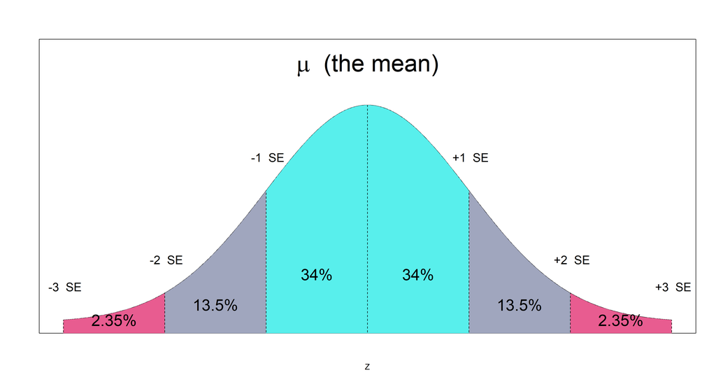

## Sampling distribution: CLT

The CLT is how we know the margin of error for a survey statistic: its the range that would contain 95% of sampled proportions in the sampling distribution.

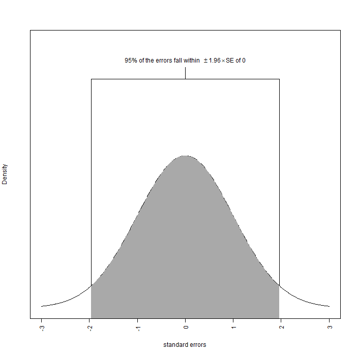

## Sampling distribution: CLT

$$.48 (1-.48) \approx .25$$

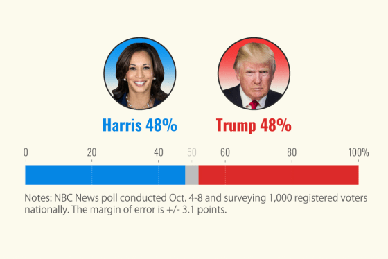

## Sampling distribution: CLT

- One key challenge here, is that the Central Limit Theorem assumes simple random sampling with replacement, but this isn’t what we typically have in survey data.
- Accounting for these differences adds some additional complexity.

## Sample designs

### Simple random samples

- In simple random samples, all elements have an equal probability of being selected.
- This is the simplest method, but its also exceedingly rare in surveys because its inefficient.

## Cluster-sampling

- In a cluster sample, “groups” of observations are sampled instead of sampling each individual.
- For instance: a survey of students might randomly select 50 classes and then interview all students in those classes.

### Cluster-sampling

- Imagine you’re gauging support for an upcoming referendum.
- You sample 2 city blocks to get an $n=100$
- (The population mean here is 50)

[figure not shown]

### Cluster-sampling

Depending on which blocks we sample, we can get some fairly bad errors here.

[figure not shown]

### Cluster-sampling

The clustered estimate is still **unbiased** (the mean of the samples = 50), but it has much **higher variance** than you would expect given the sample size.

How much larger?

[figure not shown]

### Cluster-sampling: design effects

Since we’re dealing with proportions, the variance under a simple random sample is just: $\frac{p(1-p)}{n}$

So, the variance under SRS is: $\frac{.5(1-.5)}{100} = 0.0025$

The sampling variance for the clustered samples is $\approx 0.03$, so the clustering increases the variance by $0.03/0.0025 = 12$

### Cluster-sampling: design effects

- This ratio of the clustered variance relative to the estimate is called the design effect or $d^2$.
- Note that the $d^2$ will depend on what you’re estimating and will increase or decrease depending on the amount of homogeneity within clusters with respect to the thing you’re estimating.

## Stratification

### Stratification

- Strata are *mutually exclusive* and *collectively exhaustive* subsets of the population.
- Stratified Sampling means separating the elements into strata and then drawing a sample from each one.

### Stratification

```
flowchart TB
    pop["🫧 POPULATION\nAll individuals of interest"]

    subgraph strata[" "]
        direction LR
        st1["Stratum A\ne.g. Rural areas"]
        st2["Stratum B\ne.g. Suburbs"]
        st3["Stratum C\ne.g. Urban areas"]
    end

    subgraph sampling[" "]
        direction LR
        sa1["Sample A\nn₁ individuals"]
        sa2["Sample B\nn₂ individuals"]
        sa3["Sample C\nn₃ individuals"]
    end

    combined["Combine samples\nFinal stratified sample\nn₁ + n₂ + n₃ = n"]

    note["📌 Proportional allocation:\n nᵢ / n  =  Nᵢ / N\nEach stratum represented\nproportionally to its size"]

    pop --> st1
    pop --> st2
    pop --> st3

    st1 -->|"random\nsample"| sa1
    st2 -->|"random\nsample"| sa2
    st3 -->|"random\nsample"| sa3

    sa1 --> combined
    sa2 --> combined
    sa3 --> combined

    note -..-> combined

    style pop fill:#1D4ED8,color:#fff,stroke:#1D4ED8
    style st1 fill:#065F46,color:#fff,stroke:#059669
    style st2 fill:#92400E,color:#fff,stroke:#D97706
    style st3 fill:#6B21A8,color:#fff,stroke:#A855F7
    style sa1 fill:#059669,color:#fff,stroke:#34D399
    style sa2 fill:#D97706,color:#fff,stroke:#FCD34D
    style sa3 fill:#A855F7,color:#fff,stroke:#D8B4FE
    style combined fill:#1E3A5F,color:#fff,stroke:#3B82F6
    style note fill:#1E293B,color:#94A3B8,stroke:#334155
```

### Stratification

Stratification can *reduce* sampling variance because it limits the chance of drawing highly non-representative samples.

- For instance, the ANES stratifies counties/metro areas based on vote share, turnout, and region
- This ensures that there are no potential random samples that entirely exclude very Republican or very Democratic counties.

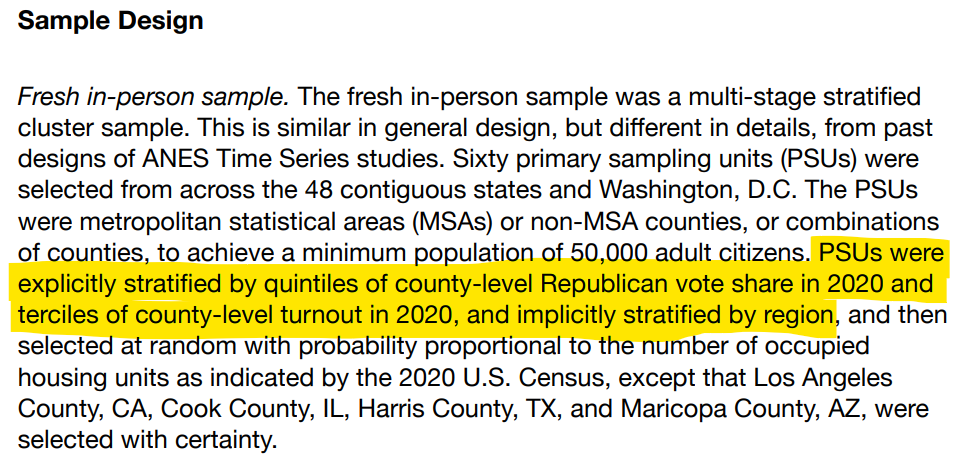

### Stratification

Think back to the example of drawing samples of n=2 from 8 student test scores

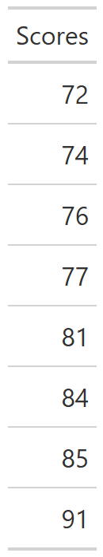

### Stratification

Consider stratifying “low” and “high” scores.

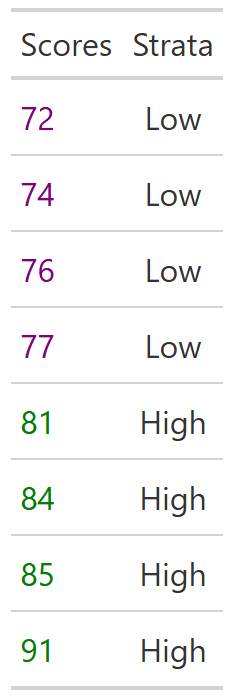

### Stratification

The “worst” samples are no longer possible here: because my sample always contains at least some “high” and some “low” scorers.

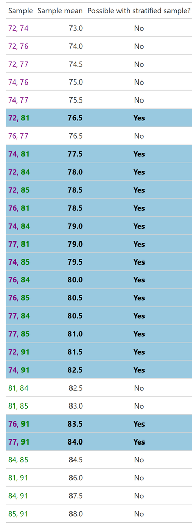

### Stratification

- Sampling variance under SRS: $16$
- Sampling variance under stratification: $4.5$
- Design effect: $.28$

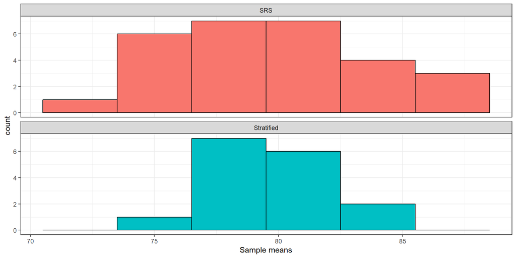

### Stratification: requirements

- Note that stratification assumes **I already have the stratification variables before I conduct the survey.** This means we’re fairly limited in the characteristics we can use.
- The benefits of stratification are largest when there’s low variability within a strata.

### Stratification: proportional allocation to strata

- Under proportional allocation to strata, the number of units selected from each strata is proportional to the size of the strata in the population.
- These designs are considered “self-weighting”: they’re already representative of the population.

### Stratification: disproportionate allocation

- Under some conditions, disproportionate allocation may further reduce sampling variance, although this is risky.
- Disproportionate allocation can make it more feasible to study certain subgroups: if I want to get reliable estimates of the views of Alaskans (.2% of the population), I’d otherwise need a huge sample.

### Stratification: disproportionate allocation

- Under disproportionate allocation to strata, strata means must be re-weighted to account for over-representation of certain groups.
- For example: if strata A is $12\%$ of the population but $24\%$ of the sample, then each individual respondent in strata A would be given a weight of $12/24 = .5$

### Multi-stage sampling

Multi-stage sampling is when population units can be divided into clusters and multiple stages of sampling are required

- For the first stage, a sample is drawn from the clusters: Primary Sampling Units (PSUs).
- For the second stage, a sample is drawn from the units within the sampled clusters: Secondary Sampling Units (SSUs).

### Multi-stage sampling

Examples:

- Select 100s school randomly in MD, sample randomly in each school.
- Stage 1 = Census blocks, Stage 2 = households

### Finite population corrections

- Survey samples are typically drawn without replacement, meaning that no element should be sampled more than once.
- When the sample is only a small share of the population, the effect of this is trivial, but it can influence estimates when the sampling fraction is large.

### Finite population corrections

The finite population correction adjusts the estimated variance to account for this:

$$v(\bar{y}) = \frac{1-f}{n} s^2$$

where $f$ is the fraction of the population that was sampled.

For most surveys, $f$ miniscule, so this doesn’t matter much!

### Non-response weights

- Stratification isn’t the only thing we need to account for.
- Even where our sampling strategy is perfect, issues like differential non-response pose major problems for representativeness.
- Weighting offers some (imperfect) methods to mitigate this as well.

[figure not shown]

### Snowball Samples

- Snowball samples are a common way to survey hard-to-reach populations or groups: people involved in organized crime, people without a permanent address, trans youth etc.
- They work like a chain letter, where a small number of respondents are identified, and then asked to recommend others who are also part of the sampling frame.

For small, densely connected communities, a snowball sample may allow researchers to get something approaching the full population.

### Convenience Samples

- The survey for this class is best described as a convenience sample. We’re not really making any effort to retrieve a representative sample of the population.
- This means we can’t really generalize the results to the population, but convenience samples can still be useful, especially for something like piloting a survey.

## References

Groves, Robert M., Floyd J. Fowler, Mick P. Couper, James M. Lepkowski, Eleanor Singer, and Roger Tourangeau. 2009. *Survey Methodology*. 2nd ed. Hoboken, NJ: John Wiley & Sons.